# IODS course project

### Linear discriminant analysis (LDA)

Fitting and printing the LDA model.

```r
# fitting the model
lda.fit <- lda(crim ~ ., data = train)
lda.fit
```

```
## Call:
## lda(crim ~ ., data = train)
##
## Prior probabilities of groups:
##       low   med_low  med_high      high
## 0.2500000 0.2599010 0.2376238 0.2524752
##
## Group means:
##                   zn      indus        chas        nox          rm
## low       1.03829437 -0.9099850 -0.11640431 -0.8969258  0.42508576
## med_low  -0.08909535 -0.2791634  0.02764047 -0.5492723 -0.12440035
## med_high -0.41399175  0.2905421  0.21980846  0.4063439 -0.04417859
## high     -0.48724019  1.0171096 -0.07933396  1.0461593 -0.35185965
##                 age        dis        rad        tax     ptratio
## low      -0.8996952  0.9208464 -0.6816778 -0.7329204 -0.45783007
## med_low  -0.3064539  0.3580487 -0.5345159 -0.4541547 -0.03840865
## med_high  0.3982212 -0.3555565 -0.4100303 -0.2660002 -0.13872186
## high      0.8085724 -0.8436870  1.6382099  1.5141140  0.78087177
##                black      lstat         medv
## low       0.38640248 -0.7885776  0.489269981
## med_low   0.31316388 -0.1329956 -0.003774132
## med_high  0.05001342  0.1178424  0.045814458
## high     -0.86539898  0.9069992 -0.668205053
##
## Coefficients of linear discriminants:
##                 LD1          LD2         LD3
## zn       0.10088502  0.844923693 -0.95004098
## indus    0.05358908 -0.339823551  0.03006047
## chas    -0.01302559 -0.073189368  0.11727291
## nox      0.43793466 -0.649678757 -1.44576498
## rm       0.04055790 -0.002492014 -0.14107207
## age      0.23809023 -0.203309884 -0.05954718
## dis     -0.06212879 -0.420485974  0.18224581
## rad      3.14701381  0.981426857 -0.05056546
## tax     -0.02427296 -0.058917856  0.77790329
## ptratio  0.16473431 -0.059775112 -0.28372638
## black   -0.10299762  0.006146091  0.10182653
## lstat    0.22758897 -0.331964688  0.24168642
## medv     0.12501668 -0.482958594 -0.32383971
##
## Proportion of trace:
##    LD1    LD2    LD3
## 0.9476 0.0404 0.0120
```

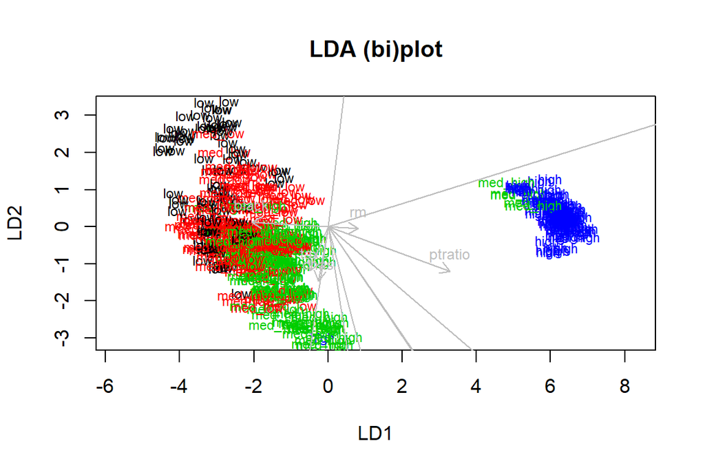

```r
# the function for lda biplot arrows
lda.arrows <- function(x, myscale = 1, arrow_heads = 0.1, color = "grey", tex = 0.75, choices = c(1,2)){
  heads <- coef(x)
  arrows(x0 = 0, y0 = 0,
         x1 = myscale * heads[,choices[1]],
         y1 = myscale * heads[,choices[2]], col=color, length = arrow_heads)
  text(myscale * heads[,choices], labels = row.names(heads),
       cex = tex, col=color, pos=3)
}

# target classes as numeric
classes <- as.numeric(train$crim)

# plot the lda results
plot(lda.fit, dimen = 2, col = classes, pch = classes, main ="LDA (bi)plot")
lda.arrows(lda.fit, myscale = 20)
```

Using test data set to predict the classes with the LDA model.

The corsstable below shows how well the LDA model predicts the crime rate in Boston suburbs. The LDA model is very accurate in predicting suburbs with high crime. Additionally, concerning suburbs with actual crime rate from low to medium high, the LDA model predicts crime rate rather accurately in the same region even if the prediction is not as accurate as with suburbs with high crome rate.

```r
# fitting the model
lda.predict <- predict(lda.fit, newdata = test)

# predicted values
Predicted <- lda.predict$class

# table of predicted vs. correct classes
descr::crosstab(Correct, Predicted, prop.r = T, plot = F)
```

```
##    Cell Contents
## |-------------------------|
## |                   Count |
## |             Row Percent |
## |-------------------------|
##
## =======================================================
##             Predicted
## Correct       low   med_low   med_high     high   Total
## -------------------------------------------------------
## low           11        13          2        0      26
##             42.3%     50.0%       7.7%     0.0%   25.5%
## -------------------------------------------------------
## med_low        3        16          2        0      21
##             14.3%     76.2%       9.5%     0.0%   20.6%
## -------------------------------------------------------
## med_high       1        10         18        1      30
##              3.3%     33.3%      60.0%     3.3%   29.4%
## -------------------------------------------------------
## high           0         0          0       25      25
##              0.0%      0.0%       0.0%   100.0%   24.5%
## -------------------------------------------------------
## Total         15        39         22       26     102
## =======================================================
```

### K-means clustering

Below is the summary of euclidian distances between observations.

```r
# the data
boston <- as_tibble(MASS::Boston)
boston_scaled <- as_tibble(scale(boston))

# distance matrix
dist_eu <- dist(boston_scaled, method = "euclidian")
summary(dist_eu)
```

```
##    Min. 1st Qu.  Median    Mean 3rd Qu.    Max.
##  0.1343  3.4625  4.8241  4.9111  6.1863 14.3970
```

Here is the first set of k-means clustering done with four clusters. For easier inspection, I only plotted tohe pairs of firts six variables in the data set.

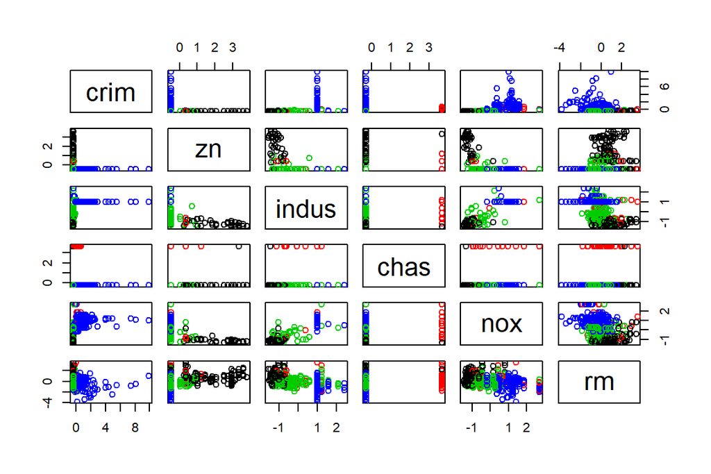

```r
km <- kmeans(boston_scaled, centers = 4)

# plot the Boston dataset with clusters
pairs(boston_scaled[1:6], col = km$cluster)
```

I investigated the correct number of cluster by checking the total of within cluster sum of squares. After determining that the optimal number of clusters is two, I plotted the clusters again.

Interpratetion: the clusters seem to vary in across several variables. Looking at the crime variable, which has been the center if interest in this exercise, it looks like that the other cluster (black), includes suburbs with higher crime rates. The other cluster, however, includes only low crime rate suburbs.

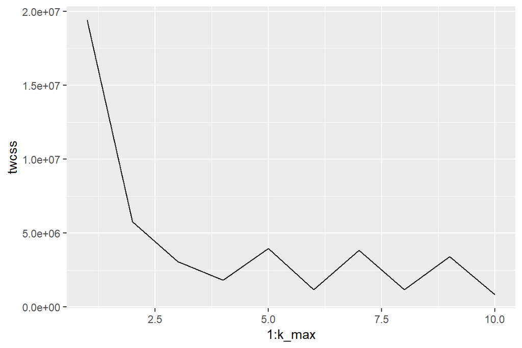

```r
# MASS, ggplot2 and Boston dataset are available
set.seed(123)

# determine the number of clusters
k_max <- 10

# calculate the total within sum of squares
twcss <- sapply(1:k_max, function(k){kmeans(Boston, k)$tot.withinss})

# visualize the results
qplot(x = 1:k_max, y = twcss, geom = 'line')
```

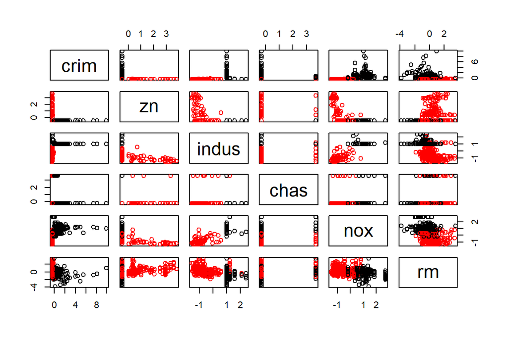

```r
# k-means clustering
km <-kmeans(boston_scaled, centers = 2)

# plot the Boston dataset with clusters
pairs(boston_scaled[1:6], col = km$cluster)
```